# Allergy and Wheeze: Risk Factor Analysis

Does atopy predict recent wheezing, and is this relationship modified by helminth infection?

2026-07-16

# Introduction

This report examines cross-sectional survey data collected from 9-year-olds attending an annual health check-up at a clinic serving a helminth-endemic, mixed peri-urban and rural population. Two questions motivate the analysis:

1. Does atopy (skin-prick test, SPT, positivity) influence the prevalence of recent wheezing?
2. Is that relationship modified by helminth infection?

A secondary aim is to assess the confounding influence of the other measured variables (sex, maternal/paternal allergy history, maternal education, and household socio-economic status).

## Analysis plan

1. Screen candidate confounders for sparse categories and missing data before any modelling.
2. Describe the sample overall and by wheeze status.
3. Test crude (unadjusted) bivariate associations between each candidate variable and wheeze (chi-square).
4. Estimate the atopy-wheeze odds ratio (OR) stratified by each candidate variable, pool it with a Mantel-Haenszel estimator, and formally test whether the OR is homogeneous across strata (Breslow-Day test). A variable whose stratum-specific ORs are not homogeneous is better treated as a potential effect modifier than as a simple confounder.
5. Build the multivariable logistic regression model in blocks, from the crude atopy effect up to the fully adjusted model, testing each addition with a likelihood-ratio test (LRT).
6. Add helminth infection and its interaction with atopy to the final model to test effect modification formally, and interpret the resulting subgroup odds ratios.

## Packages

```r
library(tidyverse)
library(haven)
library(broom)
library(correlation)
library(lmtest)
library(knitr)
library(kableExtra)
library(DescTools)
```

## Data dictionary

```r
data_dictionary <- tribble(~Variable, ~Label, ~Coding,
  "wheeze", "Wheezing in the last 12 months", "0 = No, 1 = Yes  (outcome)",
  "spt", "Atopy (skin-prick test positivity)", "0 = Negative, 1 = Positive  (main exposure)",
  "anywm", "Helminth infection (any worm)", "0 = No, 1 = Yes  (candidate effect modifier)",
  "matall", "Maternal history of allergies", "0 = No, 1 = Yes",
  "patall", "Paternal history of allergies", "0 = No, 1 = Yes",
  "sex", "Child's sex", "Assumed 1 = Male, 2 = Female -- confirm against source codebook",
  "mateducat", "Maternal education", "1 = None, 2 = Primary, 3 = Senior, 4 = Tertiary (pre-recode)",
  "hhsescat", "Household socio-economic status", "1 (lowest) - 6 (highest)  (pre-recode)"
)

kable(data_dictionary, caption = "Table 0. Variable dictionary")%>%
  kable_paper()
```

Table 0. Variable dictionary

| Variable | Label | Coding |
| --- | --- | --- |
| wheeze | Wheezing in the last 12 months | 0 = No, 1 = Yes (outcome) |
| spt | Atopy (skin-prick test positivity) | 0 = Negative, 1 = Positive (main exposure) |
| anywm | Helminth infection (any worm) | 0 = No, 1 = Yes (candidate effect modifier) |
| matall | Maternal history of allergies | 0 = No, 1 = Yes |
| patall | Paternal history of allergies | 0 = No, 1 = Yes |
| sex | Child’s sex | Assumed 1 = Male, 2 = Female – confirm against source codebook |
| mateducat | Maternal education | 1 = None, 2 = Primary, 3 = Senior, 4 = Tertiary (pre-recode) |
| hhsescat | Household socio-economic status | 1 (lowest) - 6 (highest) (pre-recode) |

# 1. Import data

```r
df <- read_dta("allergy.dta") %>%
  zap_labels()

tab1_vars <- c("wheeze", "sex", "spt", "anywm", "matall", "patall", "mateducat", "hhsescat")
```

# 2. Screening for sparse categories and missing data

Before recoding anything, tabulate every study variable as-is, with missing values shown as their own category. This is what motivates the category merges in the next step, and confirms which variables have missing data at all.

```r
tab1_initial <- df %>%
  select(all_of(tab1_vars)) %>%
  mutate(across(everything(), as.character)) %>%
  mutate(across(everything(), ~ replace_na(.x, "Missing"))) %>%
  pivot_longer(cols = everything(), names_to = "Variable", values_to = "Category") %>%
  count(Variable, Category, name = "N") %>%
  group_by(Variable) %>%
  mutate(
    Percentage = (N / sum(N)) * 100,
    Percentage_Formatted = sprintf("%.1f%%", Percentage)
  ) %>%
  ungroup()

# small helper so the interpretive text below can pull specific cells
get_pct <- function(tbl, var, cat) {
  out <- tbl %>%
    filter(Variable == var, Category == as.character(cat)) %>%
    pull(Percentage_Formatted)
  if (length(out) == 0) NA_character_ else out
}

kable(tab1_initial %>%
        select(-Percentage), caption = "Table 1. Full sample, pre-recode, missing shown as its own category", align = "c")%>%
  kable_paper()
```

Table 1. Full sample, pre-recode, missing shown as its own category

| Variable | Category | N | Percentage_Formatted |
| --- | --- | --- | --- |
| anywm | 0 | 1992 | 82.0% |
| anywm | 1 | 436 | 18.0% |
| hhsescat | 1 | 127 | 5.2% |
| hhsescat | 2 | 161 | 6.6% |
| hhsescat | 3 | 693 | 28.5% |
| hhsescat | 4 | 687 | 28.3% |
| hhsescat | 5 | 584 | 24.1% |
| hhsescat | 6 | 170 | 7.0% |
| hhsescat | Missing | 6 | 0.2% |
| matall | 0 | 1851 | 76.2% |
| matall | 1 | 577 | 23.8% |
| mateducat | 1 | 61 | 2.5% |
| mateducat | 2 | 1151 | 47.4% |
| mateducat | 3 | 958 | 39.5% |
| mateducat | 4 | 258 | 10.6% |
| patall | 0 | 2186 | 90.0% |
| patall | 1 | 242 | 10.0% |
| sex | 1 | 1312 | 54.0% |
| sex | 2 | 1116 | 46.0% |
| spt | 0 | 1728 | 71.2% |
| spt | 1 | 700 | 28.8% |
| wheeze | 0 | 2146 | 88.4% |
| wheeze | 1 | 282 | 11.6% |

0.2% of the sample is missing household SES (hhsescat); no other variable has any missing values. The smallest categories are hhsescat = 1 (5.2%) and hhsescat = 6 (7.0%), and mateducat = 1, “none” (2.5%). Therefore, I merged hhsescat 1 with 2 and hhsescat 6 with 5, as well as mateducat 1 (“none”) with 2 (“primary”) below, to avoid unstable estimates in strata with very few observations.

# 3. Recode sparse categories

```r
df <- df %>%
  mutate(
    hhsescat  = case_match(hhsescat,  c(5, 6) ~ 5, .default = hhsescat),
    hhsescat  = case_match(hhsescat,  c(1, 2) ~ 2, .default = hhsescat),
    mateducat = case_match(mateducat, 1        ~ 2, .default = mateducat)
  )
```

hhsescat now has four levels (2-5, low to high) and mateducat has three (2 = primary/none, 3 = senior, 4 = tertiary).

# 4. Descriptive characteristics by wheeze status

```r
tab1_desc_vars <- c("sex", "spt", "anywm", "matall", "patall", "mateducat", "hhsescat")

tab1_by_wheeze <- df %>%
  filter(!is.na(wheeze)) %>%
  select(wheeze, all_of(tab1_desc_vars)) %>%
  mutate(across(all_of(tab1_desc_vars), as.character)) %>%
  mutate(across(all_of(tab1_desc_vars), ~ replace_na(.x, "Missing"))) %>%
  pivot_longer(cols = all_of(tab1_desc_vars), names_to = "Variable", values_to = "Category") %>%
  count(wheeze, Variable, Category, name = "N") %>%
  group_by(wheeze, Variable) %>%
  mutate(Percentage = round((N / sum(N)) * 100, 1)) %>%
  ungroup() %>%
  mutate(wheeze_label = if_else(wheeze == 1, "Wheezing", "Non-wheezing")) %>%
  select(-wheeze) %>%
  pivot_wider(
    names_from = wheeze_label,
    values_from = c(N, Percentage),
    names_glue = "{wheeze_label}_{.value}"
  ) %>%
  select(Variable, Category, starts_with("Non-wheezing"), starts_with("Wheezing"))

n_total   <- nrow(df %>%
                    filter(!is.na(wheeze)))
n_wheeze  <- sum(df$wheeze == 1, na.rm = TRUE)
pct_wheeze <- round(100 * n_wheeze / n_total, 1)

kable(tab1_by_wheeze, align = "c", caption = "Table 2. Sample characteristics by wheeze status (recoded categories, missing shown)")%>%
  kable_paper()
```

Table 2. Sample characteristics by wheeze status (recoded categories, missing shown)

| Variable | Category | Non-wheezing_N | Non-wheezing_Percentage | Wheezing_N | Wheezing_Percentage |
| --- | --- | --- | --- | --- | --- |
| anywm | 0 | 1749 | 81.5 | 243 | 86.2 |
| anywm | 1 | 397 | 18.5 | 39 | 13.8 |
| hhsescat | 2 | 258 | 12.0 | 30 | 10.6 |
| hhsescat | 3 | 648 | 30.2 | 45 | 16.0 |
| hhsescat | 4 | 607 | 28.3 | 80 | 28.4 |
| hhsescat | 5 | 627 | 29.2 | 127 | 45.0 |
| hhsescat | Missing | 6 | 0.3 | NA | NA |
| matall | 0 | 1712 | 79.8 | 139 | 49.3 |
| matall | 1 | 434 | 20.2 | 143 | 50.7 |
| mateducat | 2 | 1112 | 51.8 | 100 | 35.5 |
| mateducat | 3 | 833 | 38.8 | 125 | 44.3 |
| mateducat | 4 | 201 | 9.4 | 57 | 20.2 |
| patall | 0 | 1978 | 92.2 | 208 | 73.8 |
| patall | 1 | 168 | 7.8 | 74 | 26.2 |
| sex | 1 | 1130 | 52.7 | 182 | 64.5 |
| sex | 2 | 1016 | 47.3 | 100 | 35.5 |
| spt | 0 | 1613 | 75.2 | 115 | 40.8 |
| spt | 1 | 533 | 24.8 | 167 | 59.2 |

# 5. Handling the missing hhsescat values

hhsescat is the only variable with missing values, affecting 0.2% of the sample. Since this is a very small fraction of the data and there is no indication these values are missing in a way related to wheeze status, these children are dropped from all analyses below so that every table and model from here on is fit on one identical, consistent sample.

```r
df_analytic <- df %>% filter(!is.na(hhsescat))


stopifnot(
  sum(colSums(is.na(df_analytic[, c("wheeze", "spt", "anywm", "matall", "patall",
                                    "sex", "mateducat", "hhsescat")]))) == 0
)

n_analytic <- nrow(df_analytic)
```

The analytic sample is 2422 children (6 excluded for missing hhsescat), complete on every variable used below.

# 6. Spearman correlations

Spearman’s rho (not Pearson’s r) is the appropriate correlation for these binary/ordinal variables, since Pearson’s correlation assumes continuous, roughly interval-scaled data.

```r
corr_result <- df_analytic %>%
  select(sex, matall, patall, spt, anywm, mateducat, hhsescat) %>%
  correlation(method = "spearman") %>%
  as_tibble()

corr_result %>%
  select(Parameter1, Parameter2, rho, p, n_Obs) %>%
  kable(digits = 3, align = "c", caption = "Table 3. Spearman correlations among candidate confounders")%>%
  kable_paper()
```

Table 3. Spearman correlations among candidate confounders

| Parameter1 | Parameter2 | rho | p | n_Obs |
| --- | --- | --- | --- | --- |
| sex | matall | -0.050 | 0.083 | 2422 |
| sex | patall | -0.059 | 0.025 | 2422 |
| sex | spt | -0.077 | 0.001 | 2422 |
| sex | anywm | -0.035 | 0.421 | 2422 |
| sex | mateducat | 0.032 | 0.482 | 2422 |
| sex | hhsescat | -0.014 | 0.555 | 2422 |
| matall | patall | 0.215 | 0.000 | 2422 |
| matall | spt | 0.107 | 0.000 | 2422 |
| matall | anywm | 0.022 | 0.555 | 2422 |
| matall | mateducat | 0.087 | 0.000 | 2422 |
| matall | hhsescat | 0.075 | 0.002 | 2422 |
| patall | spt | 0.116 | 0.000 | 2422 |
| patall | anywm | 0.031 | 0.482 | 2422 |
| patall | mateducat | 0.138 | 0.000 | 2422 |
| patall | hhsescat | 0.091 | 0.000 | 2422 |
| spt | anywm | -0.071 | 0.004 | 2422 |
| spt | mateducat | 0.108 | 0.000 | 2422 |
| spt | hhsescat | 0.098 | 0.000 | 2422 |
| anywm | mateducat | -0.094 | 0.000 | 2422 |
| anywm | hhsescat | -0.081 | 0.001 | 2422 |
| mateducat | hhsescat | 0.154 | 0.000 | 2422 |

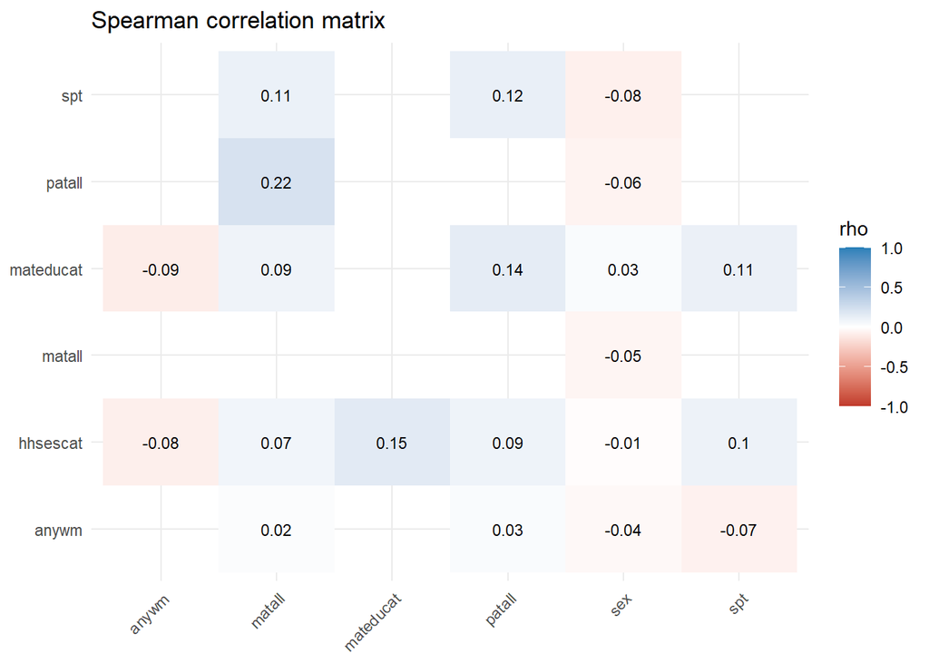

```r
corr_result %>%
  ggplot(aes(x = Parameter1, y = Parameter2, fill = rho)) +
  geom_tile() +
  geom_text(aes(label = round(rho, 2)), size = 3) +
  scale_fill_gradient2(limits = c(-1, 1), low = "#c0392b", mid = "white", high = "#2980b9") +
  labs(title = "Spearman correlation matrix", x = NULL, y = NULL, fill = "rho") +
  theme_minimal() +
  theme(axis.text.x = element_text(angle = 45, hjust = 1))
```

```r
max_corr <- corr_result %>% slice_max(abs(rho), n = 1)
```

The strongest correlation is between matall and patall (rho = 0.215). All correlations are well below the range (roughly |rho| > 0.7-0.8) that would raise multicollinearity concerns in the regression models below.

# 7. Bivariate associations with wheeze (chi-square)

```r
chi_vars <- c("spt", "sex", "matall", "patall", "mateducat", "hhsescat", "anywm")

chi_results <- map_dfr(chi_vars, function(v) {
  tbl <- table(df_analytic[[v]], df_analytic$wheeze)
  test <- chisq.test(tbl, correct = FALSE)
  tibble(Variable = v, statistic = unname(test$statistic), df = unname(test$parameter), p.value = test$p.value)
})

kable(chi_results, digits = c(NA, 3, 0, 4), caption = "Table 4. Crude chi-square tests of association with wheeze")%>%
  kable_paper()
```

Table 4. Crude chi-square tests of association with wheeze

| Variable | statistic | df | p.value |
| --- | --- | --- | --- |
| spt | 142.768 | 1 | 0.0000 |
| sex | 14.368 | 1 | 0.0002 |
| matall | 128.214 | 1 | 0.0000 |
| patall | 93.704 | 1 | 0.0000 |
| mateducat | 42.489 | 2 | 0.0000 |
| hhsescat | 38.106 | 3 | 0.0000 |
| anywm | 3.696 | 1 | 0.0546 |

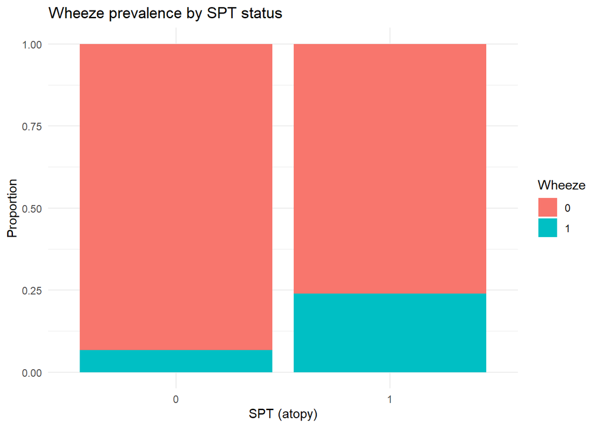

```r
df_analytic %>%
  filter(!is.na(spt), !is.na(wheeze)) %>%
  count(spt, wheeze) %>%
  group_by(spt) %>%
  mutate(pct = n / sum(n)) %>%
  ungroup() %>%
  ggplot(aes(x = factor(spt), y = pct, fill = factor(wheeze))) +
  geom_col(position = "fill") +
  labs(x = "SPT (atopy)", y = "Proportion", fill = "Wheeze",
       title = "Wheeze prevalence by SPT status") +
  theme_minimal()
```

```r
sig_vars    <- chi_results %>% filter(p.value < 0.05) %>% pull(Variable)
nonsig_vars <- chi_results %>% filter(p.value >= 0.05) %>% pull(Variable)
```

At the crude level, spt, sex, matall, patall, mateducat, hhsescat are all significantly associated with wheeze (p < .05). anywm is/are only marginally or non-significantly associated with wheeze at this unadjusted level. This crude screen only tells us these variables are related to wheeze – it doesn’t distinguish confounders from effect modifiers, which is what the stratified analysis below is for.

# 8. Stratified odds ratios, Mantel-Haenszel pooling, and homogeneity testing

For each candidate variable, this section estimates the atopy-wheeze odds ratio separately within each stratum (exact/Fisher), pools those strata into a single Mantel-Haenszel-adjusted odds ratio, and tests whether the stratum-specific odds ratios are homogeneous (Breslow-Day test). A significant Breslow-Day test means the odds ratio is not constant across strata of that variable – i.e., that variable is a candidate effect modifier, and pooling its strata into one adjusted OR risks averaging over a real subgroup difference rather than removing confounding.

```r
strat_vars <- c("sex", "matall", "patall", "mateducat", "hhsescat", "anywm")

stratum_or <- function(data, outcome, exposure, strata_var) {
  data %>%
    filter(!is.na(.data[[strata_var]])) %>%
    group_by(level = .data[[strata_var]]) %>%
    group_modify(~ tidy(fisher.test(table(.x[[exposure]], .x[[outcome]])))) %>%
    ungroup() %>%
    mutate(stratifying_variable = strata_var, .before = 1)
}

mh_and_bd <- function(data, outcome, exposure, strata_var) {
  complete <- data %>%
    filter(!is.na(.data[[strata_var]]), !is.na(.data[[exposure]]), !is.na(.data[[outcome]]))
  tbl <- table(complete[[exposure]], complete[[outcome]], complete[[strata_var]])

  mh <- mantelhaen.test(tbl, correct = FALSE)
  bd <- BreslowDayTest(tbl)

  tibble(
    stratifying_variable = strata_var,
    OR        = unname(mh$estimate),
    conf.low  = mh$conf.int[1],
    conf.high = mh$conf.int[2],
    mh_p      = mh$p.value,
    bd_statistic = unname(bd$statistic),
    bd_df        = unname(bd$parameter),
    bd_p         = bd$p.value
  )
}
```

```r
stratified_results <- map_dfr(strat_vars, ~ stratum_or(df_analytic, "wheeze", "spt", .x))

crude <- fisher.test(table(df_analytic$spt, df_analytic$wheeze))
crude_row <- tibble(
  stratifying_variable = "None (crude)",
  OR = unname(crude$estimate), conf.low = crude$conf.int[1], conf.high = crude$conf.int[2],
  mh_p = crude$p.value, bd_statistic = NA_real_, bd_df = NA_integer_, bd_p = NA_real_
)

mh_bd_results <- map_dfr(strat_vars, ~ mh_and_bd(df_analytic, "wheeze", "spt", .x))
table2 <- bind_rows(crude_row, mh_bd_results)
```

```r
stratified_results %>%
  select(stratifying_variable, level, estimate, conf.low, conf.high, p.value) %>%
  kable(digits = 3, caption = "Table 5. Stratum-specific exact odds ratios (atopy vs wheeze)")%>%
  kable_paper()
```

Table 5. Stratum-specific exact odds ratios (atopy vs wheeze)

| stratifying_variable | level | estimate | conf.low | conf.high | p.value |
| --- | --- | --- | --- | --- | --- |
| sex | 1 | 5.634 | 3.984 | 8.035 | 0.000 |
| sex | 2 | 2.713 | 1.739 | 4.216 | 0.000 |
| matall | 0 | 3.378 | 2.342 | 4.877 | 0.000 |
| matall | 1 | 5.071 | 3.327 | 7.808 | 0.000 |
| patall | 0 | 3.787 | 2.801 | 5.133 | 0.000 |
| patall | 1 | 5.146 | 2.743 | 9.940 | 0.000 |
| mateducat | 2 | 3.677 | 2.370 | 5.709 | 0.000 |
| mateducat | 3 | 3.395 | 2.272 | 5.098 | 0.000 |
| mateducat | 4 | 9.379 | 4.489 | 20.966 | 0.000 |
| hhsescat | 2 | 7.032 | 2.970 | 17.236 | 0.000 |
| hhsescat | 3 | 2.483 | 1.249 | 4.835 | 0.005 |
| hhsescat | 4 | 2.559 | 1.555 | 4.235 | 0.000 |
| hhsescat | 5 | 6.603 | 4.290 | 10.305 | 0.000 |
| anywm | 0 | 4.870 | 3.645 | 6.534 | 0.000 |
| anywm | 1 | 2.140 | 0.982 | 4.504 | 0.041 |

```r
kable(table2, digits = 3,
      caption = "Table 6. Crude and Mantel-Haenszel-adjusted odds ratios for atopy-wheeze, with Breslow-Day homogeneity tests")%>%
  kable_paper()
```

Table 6. Crude and Mantel-Haenszel-adjusted odds ratios for atopy-wheeze, with Breslow-Day homogeneity tests

| stratifying_variable | OR | conf.low | conf.high | mh_p | bd_statistic | bd_df | bd_p |
| --- | --- | --- | --- | --- | --- | --- | --- |
| None (crude) | 4.375 | 3.360 | 5.713 | 0 | NA | NA | NA |
| sex | 4.300 | 3.321 | 5.567 | 0 | 7.172 | 1 | 0.007 |
| matall | 4.069 | 3.126 | 5.296 | 0 | 2.242 | 1 | 0.134 |
| patall | 4.053 | 3.119 | 5.265 | 0 | 0.853 | 1 | 0.356 |
| mateducat | 4.137 | 3.192 | 5.361 | 0 | 6.744 | 2 | 0.034 |
| hhsescat | 4.177 | 3.224 | 5.411 | 0 | 13.334 | 3 | 0.004 |
| anywm | 4.362 | 3.370 | 5.647 | 0 | 4.687 | 1 | 0.030 |

Fisher’s exact confidence intervals are inverted from the same test as the p-value; in a small stratum (few children who are both exposed on the stratifying variable and wheezing), the interval can appear to graze 1 even when the two-sided p-value is below .05. Treat any stratum with a wide or borderline interval above with that caveat in mind.

```r
effect_modifiers <- table2 %>% filter(!is.na(bd_p), bd_p < 0.05) %>% pull(stratifying_variable)
confounders_only  <- table2 %>% filter(!is.na(bd_p), bd_p >= 0.05) %>% pull(stratifying_variable)
```

The Breslow-Day tests indicate significant heterogeneity in the atopy-wheeze odds ratio across levels of sex, mateducat, hhsescat, anywm (p < .05) – these behave as candidate effect modifiers rather than pure confounders. matall, patall show(s) no significant heterogeneity and can reasonably be treated as confounders, pooled via the Mantel-Haenszel estimate above. Helminth infection (anywm) is carried forward into the regression model below with an explicit interaction term so its effect-modifying role can be tested and quantified directly, adjusting for the other covariates at the same time.

# 9. Multivariable logistic regression

Models are built in blocks, from the crude atopy effect up to the fully adjusted model:

1. Atopy alone.
2. Parental allergy history added.
3. Sex, maternal education, household SES added.
4. Helminth infection and the atopy x helminth infection interaction added.

```r
m1 <- glm(wheeze ~ spt, data = df_analytic, family = binomial)

m2 <- glm(wheeze ~ spt + matall + patall, data = df_analytic, family = binomial)

m3 <- glm(wheeze ~ spt + matall + patall + sex + factor(mateducat) + factor(hhsescat),
          data = df_analytic, family = binomial)

m4 <- glm(wheeze ~ spt * anywm + matall + patall + sex + factor(mateducat) + factor(hhsescat),
          data = df_analytic, family = binomial)
```

Because df_analytic was already checked to be complete on every variable used here (Section 5), all four models are fit on the same 2422-observation sample, so they are directly comparable and the likelihood-ratio tests below are valid without any further complete-case refitting.

```r
term_labels <- c(
  "(Intercept)"= "Constant",
  "spt" = "Atopy (SPT positive)",
  "matall" = "Maternal allergy history",
  "patall" = "Paternal allergy history",
  "sex" = "Sex",
  "factor(mateducat)3" = "Maternal education: Senior (ref. Primary/None)",
  "factor(mateducat)4" = "Maternal education: Tertiary (ref. Primary/None)",
  "factor(hhsescat)3" = "Household SES: 3 (ref. 2)",
  "factor(hhsescat)4" = "Household SES: 4 (ref. 2)",
  "factor(hhsescat)5" = "Household SES: 5 (ref. 2)",
  "anywm" = "Helminth infection",
  "spt:anywm" = "Atopy x Helminth infection (interaction)"
)

tidy_or_table <- function(model) {
  beta <- tidy(model, exponentiate = FALSE, conf.int = FALSE) %>%
    select(term, std.error_logit = std.error)

  tidy(model, exponentiate = TRUE, conf.int = TRUE) %>%
    left_join(beta, by = "term") %>%
    mutate(
      SE_OR = estimate * std.error_logit,
      Predictor = if_else(term %in% names(term_labels), unname(term_labels[term]), term)
    ) %>%
    select(Predictor, term, OR = estimate, SE = SE_OR, z = statistic, p.value, conf.low, conf.high)
}
```

```r
table3 <- tidy_or_table(m4) %>%
  select(-term)

kable(table3, digits = 3, caption = "Table 7. Final adjusted logistic regression model for wheeze (Model 4)")%>%
  kable_paper()
```

Table 7. Final adjusted logistic regression model for wheeze (Model 4)

| Predictor | OR | SE | z | p.value | conf.low | conf.high |
| --- | --- | --- | --- | --- | --- | --- |
| Constant | 0.093 | 0.029 | -7.715 | 0.000 | 0.050 | 0.169 |
| Atopy (SPT positive) | 3.850 | 0.585 | 8.872 | 0.000 | 2.863 | 5.198 |
| Helminth infection | 0.900 | 0.226 | -0.419 | 0.675 | 0.540 | 1.450 |
| Maternal allergy history | 3.270 | 0.473 | 8.194 | 0.000 | 2.462 | 4.341 |
| Paternal allergy history | 2.459 | 0.451 | 4.901 | 0.000 | 1.708 | 3.512 |
| Sex | 0.700 | 0.101 | -2.467 | 0.014 | 0.526 | 0.928 |
| Maternal education: Senior (ref. Primary/None) | 1.449 | 0.225 | 2.382 | 0.017 | 1.068 | 1.968 |
| Maternal education: Tertiary (ref. Primary/None) | 1.669 | 0.362 | 2.365 | 0.018 | 1.086 | 2.541 |
| Household SES: 3 (ref. 2) | 0.368 | 0.098 | -3.766 | 0.000 | 0.219 | 0.623 |
| Household SES: 4 (ref. 2) | 0.582 | 0.145 | -2.176 | 0.030 | 0.360 | 0.957 |
| Household SES: 5 (ref. 2) | 0.901 | 0.213 | -0.441 | 0.659 | 0.573 | 1.449 |
| Atopy x Helminth infection (interaction) | 0.427 | 0.177 | -2.057 | 0.040 | 0.187 | 0.951 |

```r
model_list <- list("Model 1" = m1, "Model 2" = m2, "Model 3" = m3, "Model 4" = m4)

model_comparison <- map(model_list, tidy_or_table) %>%
  list_rbind(names_to = "Model") %>%
  mutate(
    `OR (95% CI)` = sprintf("%.2f (%.2f, %.2f)", OR, conf.low, conf.high),
    p = sprintf("%.3f", p.value)
  ) %>%
  select(Predictor, term, Model, `OR (95% CI)`, p) %>%
  pivot_wider(names_from = Model, values_from = c(`OR (95% CI)`, p), names_glue = "{Model}: {.value}") %>%
  select(Predictor, starts_with("Model 1"), starts_with("Model 2"), starts_with("Model 3"), starts_with("Model 4"))

kable(model_comparison, caption = "Table 8. Odds ratios (95% CI) and p-values across all four nested models")%>%
  kable_paper()
```

Table 8. Odds ratios (95% CI) and p-values across all four nested models

| Predictor | Model 1: OR (95% CI) | Model 1: p | Model 2: OR (95% CI) | Model 2: p | Model 3: OR (95% CI) | Model 3: p | Model 4: OR (95% CI) | Model 4: p |
| --- | --- | --- | --- | --- | --- | --- | --- | --- |
| Constant | 0.07 (0.06, 0.09) | 0.000 | 0.04 (0.04, 0.06) | 0.000 | 0.09 (0.05, 0.16) | 0.000 | 0.09 (0.05, 0.17) | 0.000 |
| Atopy (SPT positive) | 4.38 (3.39, 5.67) | 0.000 | 3.78 (2.90, 4.95) | 0.000 | 3.51 (2.68, 4.63) | 0.000 | 3.85 (2.86, 5.20) | 0.000 |
| Maternal allergy history | NA | NA | 3.16 (2.40, 4.15) | 0.000 | 3.14 (2.37, 4.16) | 0.000 | 3.27 (2.46, 4.34) | 0.000 |
| Paternal allergy history | NA | NA | 2.53 (1.79, 3.55) | 0.000 | 2.31 (1.61, 3.29) | 0.000 | 2.46 (1.71, 3.51) | 0.000 |
| Sex | NA | NA | NA | NA | 0.71 (0.54, 0.94) | 0.018 | 0.70 (0.53, 0.93) | 0.014 |
| Maternal education: Senior (ref. Primary/None) | NA | NA | NA | NA | 1.46 (1.08, 1.99) | 0.014 | 1.45 (1.07, 1.97) | 0.017 |
| Maternal education: Tertiary (ref. Primary/None) | NA | NA | NA | NA | 1.83 (1.20, 2.77) | 0.004 | 1.67 (1.09, 2.54) | 0.018 |
| Household SES: 3 (ref. 2) | NA | NA | NA | NA | 0.39 (0.23, 0.65) | 0.000 | 0.37 (0.22, 0.62) | 0.000 |
| Household SES: 4 (ref. 2) | NA | NA | NA | NA | 0.59 (0.37, 0.97) | 0.033 | 0.58 (0.36, 0.96) | 0.030 |
| Household SES: 5 (ref. 2) | NA | NA | NA | NA | 0.92 (0.59, 1.47) | 0.715 | 0.90 (0.57, 1.45) | 0.659 |
| Helminth infection | NA | NA | NA | NA | NA | NA | 0.90 (0.54, 1.45) | 0.675 |
| Atopy x Helminth infection (interaction) | NA | NA | NA | NA | NA | NA | 0.43 (0.19, 0.95) | 0.040 |

## Confounding assessment (Models 1-3)

```r
or_m1 <- tidy_or_table(m1) %>% filter(term == "spt") %>% pull(OR)
or_m2 <- tidy_or_table(m2) %>% filter(term == "spt") %>% pull(OR)
or_m3 <- tidy_or_table(m3) %>% filter(term == "spt") %>% pull(OR)

lr_m1_m2 <- lrtest(m1, m2)
lr_m2_m3 <- lrtest(m2, m3)
```

The unadjusted (Model 1) odds ratio for atopy is 4.38. Adding maternal and paternal allergy history (Model 2) shifts it to 3.78, and adding sex, maternal education, and household SES (Model 3) shifts it further to 3.51 (LRT Model 1 vs 2: chi-sq = 117.72, df = 2, p < .001; LRT Model 2 vs 3: chi-sq = 43.47, df = 6, p < .001). Each block is a statistically significant improvement in fit, and each adjustment attenuates but does not reverse or eliminate the atopy-wheeze association: these variables confound part of the crude association, but atopy remains strongly associated with wheeze after adjustment.

## Effect modification by helminth infection (Model 4)

```r
lr_m3_m4 <- lrtest(m3, m4)

beta_spt <- coef(m4)["spt"]
beta_int <- coef(m4)["spt:anywm"]

adj_or_no_helminth <- exp(beta_spt)
adj_or_helminth    <- exp(beta_spt + beta_int)
pct_attenuation    <- round((1 - adj_or_helminth / adj_or_no_helminth) * 100)

crude_no_helminth <- stratified_results %>%
  filter(stratifying_variable == "anywm", level == 0)%>%
  pull(estimate)
crude_helminth <- stratified_results %>%
  filter(stratifying_variable == "anywm", level == 1)%>%
  pull(estimate)
```

# 10. Discussion and conclusions

## Atopy and wheeze

Atopy is associated with substantially higher odds of recent wheezing, and this association persists (materially reduced in magnitude, but not eliminated) after adjusting for sex, parental allergy history, maternal education, and household SES (Section 9). Sex, parental allergy history, maternal education, and household SES are all significantly associated with wheeze at the bivariate level (Section 7), and confound part of the crude atopy-wheeze association (Section 9).

## Effect modification by helminth infection

Helminth infection was not, by itself, a significant predictor of wheeze in the adjusted model, but its interaction with atopy was (Section 9). The direction is consistent with the “hygiene hypothesis”-style explanation offered in the original write-up – that helminth infection may down-regulate the same Th2-mediated inflammatory pathway responsible for atopic wheeze – though this analysis cannot establish that mechanism; it can only show that the statistical association between atopy and wheeze is weaker among children with a helminth infection than among those without one.

# 11. Limitations

1. **Cross-sectional design.** Exposure and outcome are measured concurrently, limiting causal interpretation.
2. **No correction for multiple testing.** Seven bivariate chi-square tests and six stratified/homogeneity tests are run without adjustment (e.g., Bonferroni or FDR); results should be read as exploratory rather than confirmatory.
3. **No formal model diagnostics.** This report does not check goodness-of-fit (e.g., Hosmer-Lemeshow), influence/leverage, or multicollinearity via variance inflation factors, though the Spearman correlations in Section 6 did not flag any strongly correlated pairs.
4. **Unmeasured confounders.** Variables not collected here (e.g., other environmental allergen exposure, smoking in the household, prior respiratory infections) could still confound the associations reported.
5. **Generalisability.** Findings apply to a helminth-endemic, peri-urban/rural population and may not generalise to settings with a different helminth burden or allergen exposure profile.